# Atividade Prática 2

Econometria Aplicada à Finanças  
Mestrado Profissional em Administração

Autor

Prof. Dr. Washington S. da Silva

Data de Publicação

25 de agosto de 2026

## Questão 1

**a.** Ao longo da disciplina, usaremos o estimador de MQO ($\hat{\beta}$) para estimar um parâmetro populacional $\beta$ de um modelo de regressão linear. Explique, de forma intuitiva, o que significa $\hat{\beta}$ ser viesado para $\beta$.

**b.** Qual é a definição formal (matemática) de **viés**?

**c.** Por que nos importamos se o estimador de MQO (ou qualquer estimador) é **viesado**?

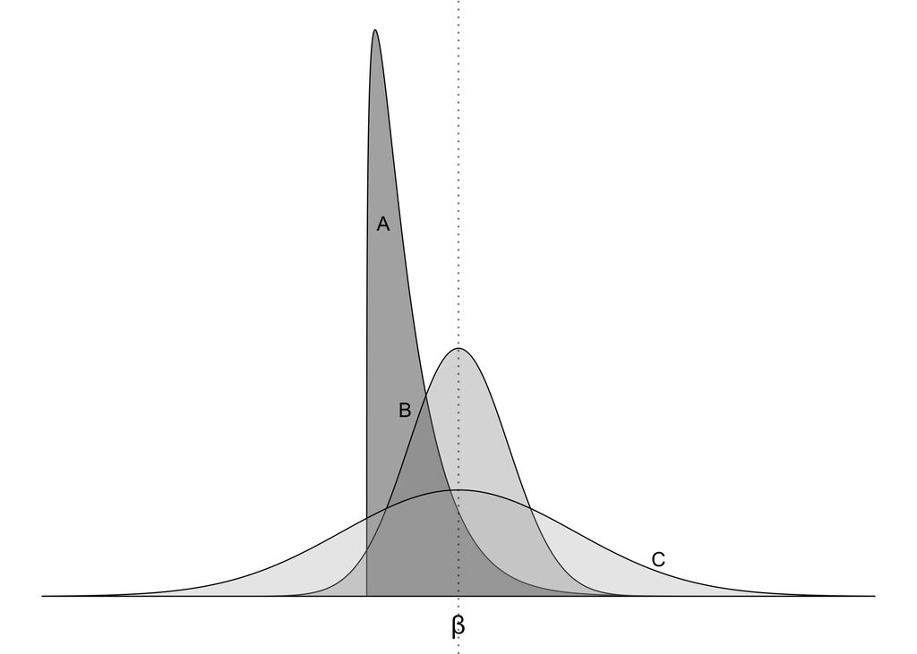

Figura 1: Distribuição Amostral de 3 Estimadores (A, B e C) do parâmetro populacional$ $\beta$.

A Fig. 1 mostra as distribuições de três estimadores (A, B e C), cada um dos quais estima o parâmetro desconhecido $\beta$, sendo que $E[A]= \beta - 3$, $E[B]= \beta$, $E[C]= \beta$.

**d.** Quais dos estimadores exibidos na Fig. 1 são não viesados? *Dica:* Pode haver mais de um.

**e.** Qual dos estimadores da Fig. 1 possui a menor variância?

**f.** Qual dos estimadores da Fig. 1 é o **melhor** estimador não viesado (i.e, com menor variância)?

**g.** O que significa o termo “erro padrão”?

**h.** **Verdadeiro/Falso**: A ausência de viés é uma propriedade para amostras de tamanho finito, enquanto a consistência refere-se a um estimador conforme o tamanho da amostra se aproxima do infinito. Explique sua opção.

## Questão 2

**NotaArquivo de dados: `data-ps1.csv`**

Os dados utilizados nesta questão são provenientes do estudo *The Association Between Income and Life Expectancy in the United States, 2001-2014*, de Raj Chetty, Augustin Bergeron, David Cutler, Benjamin Scuderi, Michael Stepner e Nicholas Turner. O estudo investiga a relação entre renda e expectativa de vida nos Estados Unidos, além de analisar como essa relação varia entre diferentes regiões do país.

Os autores disponibilizaram informações detalhadas sobre o projeto [neste website](https://opportunityinsights.org/paper/lifeexpectancy/). O artigo completo pode ser consultado na [JAMA](https://jamanetwork.com/journals/jama/fullarticle/2513561?guestAccessKey=4023ce75-d0fb-44de-bb6c-8a10a30a6173), e um resumo não técnico elaborado pelos próprios autores está disponível [aqui](https://opportunityinsights.org/wp-content/uploads/2018/03/healthineq_summary.pdf).[^1]

Um dos principais objetivos do estudo é compreender as diferenças de expectativa de vida entre grupos de renda. Os resultados mostram que essas diferenças variam consideravelmente entre regiões dos Estados Unidos: em algumas localidades, indivíduos de baixa renda apresentam expectativa de vida relativamente elevada, enquanto em outras as diferenças entre os grupos de renda são substancialmente maiores.

Os autores também investigam quais características socioeconômicas, demográficas e comportamentais estão associadas à expectativa de vida da população. Entre os fatores considerados estão pobreza, desemprego, renda domiciliar, acesso a seguro de saúde, composição demográfica e indicadores relacionados a hábitos de saúde, como tabagismo, obesidade e prática de exercícios físicos.

Nesta atividade, utilizaremos uma versão desses dados em que cada observação corresponde à combinação entre um **condado dos Estados Unidos** e um dos dois quartis de renda considerados (1 ou 4). As variáveis disponíveis são apresentadas a seguir.

Nomes e descrições das variáveis

| Nome da variável | Tipo da variável | Descrição da variável |
| --- | --- | --- |
| `county_name` | character | Nome do condado |
| `county_code` | integer | Código FIPS do condado |
| `state_abb` | character | Abreviação do estado |
| `income_quartile` | numeric | Quartil de renda (1 ou 4) |
| `life_exp` | numeric | Expectativa de vida, em anos |
| `pct_uninsured` | numeric | Proporção da população sem seguro de saúde |
| `poverty_rate` | numeric | Proporção da população abaixo da linha de pobreza |
| `pct_religious` | numeric | Proporção da população considerada religiosa |
| `pct_black` | numeric | Proporção da população negra |
| `pct_hispanic` | numeric | Proporção da população hispânica |
| `unemployment_rate` | numeric | Taxa de desemprego |
| `median_hh_inc` | numeric | Renda domiciliar mediana, em milhares de dólares |
| `is_urban` | integer | Indicador de condado urbano (1 = urbano; 0 = não urbano) |
| `pop` | integer | População do condado |
| `pop_density` | numeric | Densidade populacional |
| `pct_smoke` | numeric | Proporção da população que fuma |
| `pct_obese` | numeric | Proporção da população considerada obesa, segundo o BMI |
| `pct_exercise` | numeric | Proporção da população que pratica exercícios físicos |

Informações adicionais sobre as variáveis relacionadas à expectativa de vida podem ser consultadas [aqui](https://opportunityinsights.org/wp-content/uploads/2018/04/health_ineq_online_table_11_readme.pdf). A documentação das características dos condados está disponível [aqui](https://opportunityinsights.org/wp-content/uploads/2018/04/health_ineq_online_table_12_readme.pdf).

## Conheça os dados

Inicialmente, importe o arquivo e nomeie o objeto como `life_df`.

```r
# define o caminho relativo do arquivo csv com here
caminho_csv <- here::here("data/raw/data-ps1.csv")

# importa o arquivo com a função read_csv
life_df <- readr::read_csv(caminho_csv, show_col_types = FALSE)

# inspeciona o objeto importado
dplyr::glimpse(life_df)
```

Como em qualquer análise de dados, o primeiro passo é conhecer os dados com os quais iremos trabalhar.

**a.** Use `R` para informar:

- o número de observações;
- o número de variáveis;
- o número de observações completas;
- o número de condados distintos;
- o número de estados distintos;
- o número de observações em cada quartil de renda;
- o número de valores ausentes em cada variável.

*Dicas*

1. As funções `nrow()` e `ncol()` retornam, respectivamente, o número de linhas e de colunas de um conjunto de dados.
2. A função `complete.cases()` permite verificar se uma observação contém algum valor ausente.
3. A função `n_distinct()` conta o número de valores distintos.
4. A função `count()` é útil para contar observações por grupos.
5. `colSums(is.na(life_df))` conta diretamente os valores ausentes em cada variável.

**b.** Crie uma nova variável denominada `high_income`, que seja igual a `1` quando `income_quartile == 4` e igual a `0` caso contrário.

*Dica:* Dentro de `mutate()`, use `if_else()` para atribuir 1 quando `income_quartile == 4` e 0 nos demais casos.

**c.** Construa uma tabela de estatísticas descritivas que apresente a média e o desvio-padrão das seguintes variáveis para cada grupo de renda:

- expectativa de vida (`life_exp`);
- taxa de tabagismo (`pct_smoke`);
- taxa de obesidade (`pct_obese`);
- taxa de prática de exercícios físicos (`pct_exercise`).

Em uma ou duas frases, sintetize as diferenças observadas entre os grupos de renda.

*Dica:* Agrupe as observações com `group_by(income_quartile)` e calcule explicitamente cada média e desvio-padrão dentro de `summarize()` usando `mean()` e `sd()`.

## Visualize os dados

Antes de estimarmos os modelos de regressão, vamos visualizar algumas relações importantes presentes nos dados.

**d.** Construa boxplots lado a lado (`geom_boxplot`) da expectativa de vida (`life_exp`) por quartil de renda (`income_quartile`). Separe os gráficos de acordo com a condição urbana do condado (`is_urban`).

*Observação:* Certifique-se de identificar adequadamente os eixos. Também é recomendável incluir um título. As demais escolhas estéticas — cores, temas etc. — ficam a seu critério.

O código necessário é:

```r
# Boxplots da expectativa de vida por grupo de renda e condição urbana
ggplot(
  data = life_df,
  aes(x = factor(income_quartile), y = life_exp, fill = factor(income_quartile))
) +
geom_boxplot(width = 0.55, alpha = 0.85, outlier.alpha = 0.4) +
facet_wrap(
  ~ is_urban,
  labeller = as_labeller(c('0' = 'Condado não urbano', '1' = 'Condado urbano'))
) +
scale_y_continuous('Expectativa de vida', labels = comma) +
scale_x_discrete(
  'Quartil de renda',
  labels = c('1' = 'Mais baixo', '4' = 'Mais alto')
) +
scale_fill_viridis_d(
  option = 'mako',
  begin = 0.25,
  end = 0.75,
  guide = 'none'
) +
theme_minimal(base_size = 12, base_family = 'Fira Sans Condensed') +
theme(axis.text.x = element_text(angle = 15, hjust = 1))
```

**e.** Construa um gráfico de densidade das taxas de tabagismo (`pct_smoke`) de acordo com o quartil de renda (`income_quartile`).

O código necessário é:

```r
# Gráfico de densidade das taxas de tabagismo por grupo de renda
ggplot(
  data = life_df,
  aes(x = pct_smoke, color = factor(income_quartile), fill = factor(income_quartile))
) +
geom_density(alpha = 0.35, linewidth = 0.9) +
scale_x_continuous('Taxa de tabagismo', labels = percent) +
scale_y_continuous('Densidade', labels = comma) +
scale_color_viridis_d(
  name = 'Quartil de renda',
  labels = c('1 (mais baixo)', '4 (mais alto)'),
  option = 'mako',
  begin = 0.25,
  end = 0.75
) +
scale_fill_viridis_d(
  name = 'Quartil de renda',
  labels = c('1 (mais baixo)', '4 (mais alto)'),
  option = 'mako',
  begin = 0.25,
  end = 0.75
) +
theme_minimal(base_size = 12, base_family = 'Fira Sans Condensed') +
theme(legend.position = 'bottom')
```

*Dica:* A função `geom_density()` funciona de maneira semelhante a `geom_histogram()`, mas apresenta uma densidade suavizada em vez da contagem de observações.

**f.** Construa um gráfico de dispersão relacionando a expectativa de vida (`life_exp`, no eixo *y*) e a taxa de tabagismo (`pct_smoke`, no eixo *x*). Utilize cores diferentes para representar os quartis de renda (`income_quartile`) e adicione uma reta de regressão linear separada para cada quartil de renda.

*Dicas*

1. Utilize a estética `color` para diferenciar os pontos de acordo com o quartil de renda.
2. Adicione `geom_smooth(method = 'lm', se = FALSE)` para incluir as retas de regressão linear ajustadas.

O código necessário é:

```r
# Gráfico de dispersão entre expectativa de vida e taxa de tabagismo
ggplot(
  data = life_df,
  aes(x = pct_smoke, y = life_exp, color = factor(income_quartile))
) +
geom_point(alpha = 0.55, size = 1.5) +
geom_smooth(method = 'lm', se = FALSE, linewidth = 1) +
scale_x_continuous('Taxa de tabagismo', labels = percent) +
scale_y_continuous('Expectativa de vida', labels = comma) +
scale_color_viridis_d(
  name = 'Quartil de renda',
  labels = c('1 (mais baixo)', '4 (mais alto)'),
  option = 'mako',
  begin = 0.25,
  end = 0.75
) +
theme_minimal(base_size = 12, base_family = 'Fira Sans Condensed') +
theme(legend.position = 'bottom')
```

**g.** Sintetize os resultados apresentados nos gráficos das questões **d.**, **e.** e **f.**. O que eles sugerem sobre a relação entre expectativa de vida, tabagismo e renda?

## Viés de variável omitida

Suponha que estejamos interessados em estimar a relação entre tabagismo e expectativa de vida:

$$\text{(Expectativa de vida)}_i = \beta_0 + \beta_1 \text{(Taxa de tabagismo)}_i + u_i.$$

**h.** Explique por que o gráfico de dispersão construído na questão **f.** sugere que o viés de variável omitida pode ser uma preocupação na estimação dessa regressão.

**i.** Com base nos sinais das relações observadas na questão **f.**, você espera que a omissão do grupo de renda produza um viés para cima ou para baixo na estimativa de MQO de $\beta_1$? Explique seu raciocínio.

**j.** Estime as duas regressões apresentadas a seguir e forneça uma tabela com os resultados:

1. A regressão simples, contendo apenas a taxa de tabagismo:

$$\text{(Expectativa de vida)}_i = \beta_0 + \beta_1 \text{(Taxa de tabagismo)}_i + u_i;$$

2. A regressão que também controla para alta renda:

$$\text{(Expectativa de vida)}_i = \beta_0 + \beta_1 \text{(Taxa de tabagismo)}_i + \beta_2 \text{(Alta renda)}_i + u_i.$$

*Dicas:* Estime os modelos com `lm()`. Para construir uma única tabela, extraia os resultados com `broom::tidy()`, reúna-os com `bind_rows()` e apresente-os com `knitr::kable()`.

**k.** Compare as estimativas de $\beta_1$ obtidas nas duas regressões da questão **j.**. A mudança observada é consistente com sua previsão na questão **i.**? Interprete os coeficientes considerando um aumento de **10 pontos percentuais** na taxa de tabagismo.

**l.** Agora estime, com `lm()`, um modelo que controle para a taxa de tabagismo, alta renda e a condição urbana do condado:

$$\text{(Expectativa de vida)}_i = \beta_0 + \beta_1 \text{(Taxa de tabagismo)}_i + \beta_2 \text{(Alta renda)}_i + \beta_3
\text{(Condado urbano)}_i + u_i$$

A inclusão do indicador de condado urbano altera de maneira relevante a estimativa do coeficiente associado ao tabagismo? Explique o que esse resultado nos revela sobre o viés de variável omitida.

## Notas de rodapé

[^1]: Os dados originais foram construídos a partir de aproximadamente 1,4 bilhão de registros anônimos de renda e mortalidade e permitiram aos autores estimar a relação entre renda e expectativa de vida em diferentes regiões dos Estados Unidos.